# BANA 4080: Introduction to Data Mining with Python

Week 11: Tree-Based Models

## Welcome to Week 11

- Quick overview of today’s plan:
  - **Decision Trees**: Learning to ask yes/no questions
  - **Random Forests**: Combining trees for better predictions
  - **Feature Importance**: Understanding what drives predictions
  - **Hands-on demos**: Build and interpret tree-based models

# Discussion: Homework & Questions

## Questions from Week 10?

- Any questions about linear or logistic regression?
- Model evaluation metrics clear?
- Confusion about train/test splits?
- Anything from the quiz or class lab?
- Time to ask!

**Activity**

Converse with your neighbor and identify…

- 1 new thing you learned last week that you thought was clear and explained well
- 1 thing we covered last week that is still confusing

# Decision Trees: Learning to Ask Questions

## Linear Models Struggle with Non-Linear Patterns

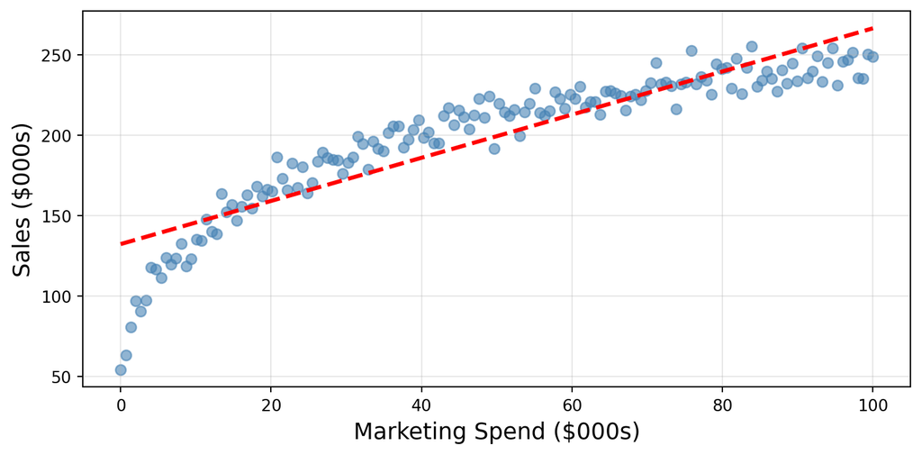

**Caution**

**Real business data rarely follows straight lines**

## Linear Models Miss Interactions

|  | **Premium Brand** | **Unknown Brand** |
| --- | --- | --- |
| **High Quality** | $200 | $80 |
| **Low Quality** | $120 | $40 |

**The Pattern:**

High quality means different things in different contexts.

Linear models struggle to capture these interactions without manual specification.

**Same Quality → Different Prices (Context Matters!)**

Same quality product gets wildly different prices based on brand. Linear models assume quality has one fixed effect - but here it depends on context.

## Linear Models Are Hard to Explain

**Option 1: Linear Model**

$$P(\text{default}) = \frac{1}{1+e^{-(\beta_0 + 0.0032 \cdot \text{balance} - 0.0015 \cdot \text{income} + ...)}}$$

*“For each $100 increase in balance, the log-odds of default increase by 0.32…”*

**Option 2: Decision Tree**

**If balance > $1,200** **Then 85% default risk**

*“If their balance is over $1,200 they have an 85% probability of defaulting.”*

**Which would you present to your boss?**

## What If There Was a Better Way?

**Decision trees offer:**

✓ Capture nonlinear patterns naturally

✓ Automatically discover thresholds

✓ Naturally handle interactions

✓ Create clear if-then rules

✓ Mirror human decision-making

## Think-Pair-Share: Your Decision Process

Think about a decision you make regularly using yes/no questions…

**Examples:**

- Deciding whether to approve a loan application
- Choosing which restaurant to visit
- Determining if a sales lead is worth pursuing
- Diagnosing a technical problem

**Discuss with your neighbor:**

1. What’s the first question you ask?
2. How does the answer change your next question?
3. How many questions until you reach a decision?

Then we’ll take a few responses…

# Decision Trees: The if-else of ML!

## How Decision Trees Work

**The Process:**

1. Start with all your data
2. Ask a yes/no question that best separates the data
3. Split data into two groups based on the answer
4. Repeat for each group until you reach clear predictions

**Example: Loan Approval**

```
Income > $50k?
├─ YES → Credit Score > 700?
│         ├─ YES → APPROVE
│         └─ NO → REVIEW
└─ NO → Has Co-signer?
          ├─ YES → CONSIDER
          └─ NO → DENY
```

```
flowchart TD
    A[Loan Application] --> B{"Income > 50K?"}
    B -->|Yes| C{"Credit Score > 700?"}
    B -->|No| D{"Has Co-signer?"}
    C -->|Yes| E[Approve]
    C -->|No| F[Review]
    D -->|Yes| G[Consider]
    D -->|No| H[Deny]

    style A fill:#e1f5fe
    style E fill:#c8e6c9
    style G fill:#fff3c4
    style F fill:#fff3c4
    style H fill:#ffcdd2
```

## Tree Anatomy: Understanding the Parts

**Key Components:**

- **Root Node**: Where all data starts
- **Internal Nodes**: Decision points (yes/no questions)
- **Branches**: Paths representing answers
- **Leaf Nodes**: Final predictions
- **Depth**: How many questions deep the tree goes

**Reading a Tree:**

- Follow the path from top to bottom
- Each split asks about ONE feature
- Leaves give you the final prediction

```
flowchart TD
    A["ROOT NODE<br/>All Data"] --> B{"INTERNAL NODE<br/>Question 1"}
    B -->|Yes| C{"INTERNAL NODE<br/>Question 2A"}
    B -->|No| D{"INTERNAL NODE<br/>Question 2B"}
    C -->|Yes| E["LEAF<br/>Prediction A"]
    C -->|No| F["LEAF<br/>Prediction B"]
    D -->|Yes| G["LEAF<br/>Prediction C"]
    D -->|No| H["LEAF<br/>Prediction D"]

    style A fill:#e3f2fd,stroke:#1976d2,stroke-width:3px
    style B fill:#fff3e0,stroke:#f57c00,stroke-width:2px
    style C fill:#fff3e0,stroke:#f57c00,stroke-width:2px
    style D fill:#fff3e0,stroke:#f57c00,stroke-width:2px
    style E fill:#e8f5e8,stroke:#388e3c,stroke-width:2px
    style F fill:#e8f5e8,stroke:#388e3c,stroke-width:2px
    style G fill:#e8f5e8,stroke:#388e3c,stroke-width:2px
    style H fill:#e8f5e8,stroke:#388e3c,stroke-width:2px
```

## How Does the Tree Decide Which Question to Ask?

**Imagine we’re predicting credit card default. Which feature split is better?**

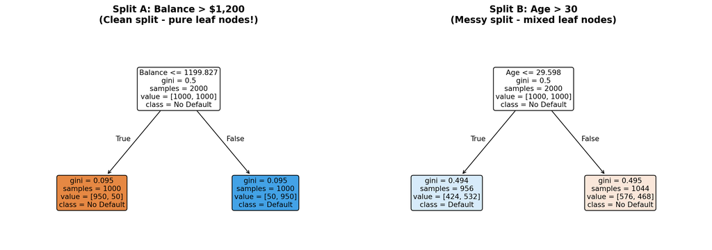

**Which split creates cleaner, more organized groups?**

**Think about it… then we’ll see how the algorithm decides!**

## CART Algorithm: Finding the Best Splits

**The algorithm formalizes what we just intuitively understood!**

**The CART Algorithm:**

1. **Test every possible split** for every feature
2. **Measure “purity”** using Gini impurity
   - Gini = 0: Perfect (all same class)
   - Gini = 0.5: Mixed (50/50 split)
3. **Choose the split** that creates the biggest purity improvement
4. **Repeat** until stopping criteria met

**Why this matters:** Trees automatically find the thresholds that matter most in your data!

**Gini Impurity: A “Messiness Meter”**

- **Low Gini (0.0 - 0.1)**: Very organized, confident predictions
- **Medium Gini (0.2 - 0.3)**: Somewhat mixed, less confident
- **High Gini (0.4 - 0.5)**: Very messy, like flipping a coin

**Business Translation:** Lower Gini = clearer business segments = more reliable rules

## Interactive Demo: Build Your First Tree

Let’s build a decision tree to predict credit card defaults!

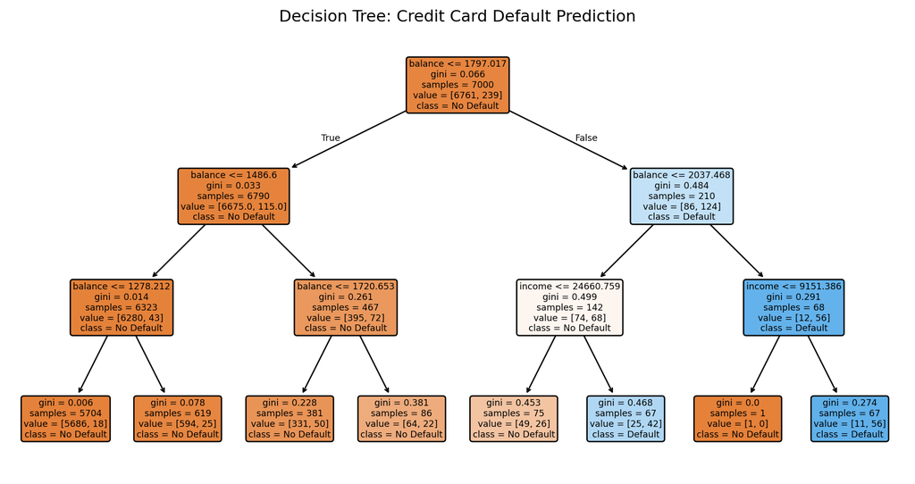

```
Training accuracy: 0.975
Test accuracy: 0.972
```

```python
# Load data and prepare features
from ISLP import load_data
from sklearn.tree import DecisionTreeClassifier, plot_tree
from sklearn.model_selection import train_test_split
import matplotlib.pyplot as plt

# Load Default dataset
Default = load_data('Default')
Default['default'] = (Default['default'] == 'Yes').astype(int)
Default['student'] = (Default['student'] == 'Yes').astype(int)

# Prepare features and target
X = Default[['student', 'balance', 'income']]
y = Default['default']

# Split data
X_train, X_test, y_train, y_test = train_test_split(X, y, test_size=0.3, random_state=42)

# Build a simple tree (max_depth=3 for interpretability)
tree_model = DecisionTreeClassifier(max_depth=3, random_state=42)
tree_model.fit(X_train, y_train)

# Visualize the tree
plt.figure(figsize=(12, 6))
plot_tree(tree_model, feature_names=['student', 'balance', 'income'], class_names=['No Default', 'Default'], filled=True, rounded=True)
plt.title("Decision Tree: Credit Card Default Prediction")
plt.show()

# Check accuracy
print(f"Training accuracy: {tree_model.score(X_train, y_train):.3f}")
print(f"Test accuracy: {tree_model.score(X_test, y_test):.3f}")
```

# Random Forests: Wisdom of Crowds

## The Problem with Single Trees

**Warning**

Decision trees are interpretable, but they have two critical weaknesses:

1. **Instability**
2. **Overfitting**

Let’s see what these problems look like…

## Problem #1: Instability

**Small changes in data → completely different trees**

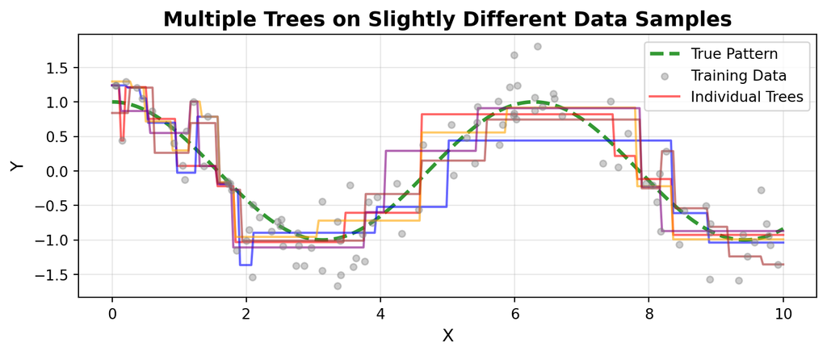

**The Problem:**

- Each colored line is a different tree
- Same data, just sampled differently
- Trees make very different predictions!

**Business Impact:**

- Unreliable predictions
- Inconsistent insights
- Hard to trust for decisions

## Problem #2: Overfitting

**Trees memorize training data instead of learning patterns**

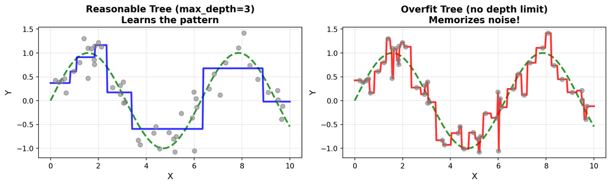

**The Problem:**

- Left tree captures the pattern ✓
- Right tree memorizes every point
- Wildly jagged - chasing noise, not signal

**Business Impact:**

- Perfect training accuracy (1.00)
- Poor test accuracy (0.75)
- Unreliable on new data

## Think-Pair-Share: Why Consult Multiple Experts?

When making important decisions, we rarely trust just one opinion…

**Real-world examples:**

- Hiring: Interview panel (not just one person)
- Medical diagnosis: Second opinions for serious conditions
- Restaurant choice: Check multiple review sites
- Investment decisions: Consult multiple analysts

**Discuss with your neighbor:**

1. Why is averaging multiple opinions more reliable than trusting one expert?
2. What makes a good “panel of experts” (rather than just asking the same person twice)?
3. How might this apply to machine learning?

Then we’ll take a few responses…

## Random Forests: Two Key Ingredients

Random Forests improve on single decision trees through two main modifications:

**1. Bootstrap Aggregating (Bagging)**

Train many trees on different random samples of data

**2. Feature Randomness**

Each tree considers only a random subset of features at each split

**Let’s see how each one works…**

## Bootstrap Aggregating (Bagging)

**Creating diversity through random sampling**

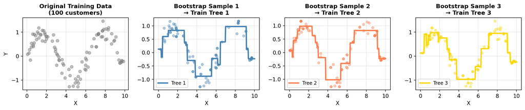

**The Process:** Original data → 3 bootstrap samples → Train 3 different trees → Aggregate predictions!

## The Problem with Bagging Alone

**What if one feature is much stronger than the others?**

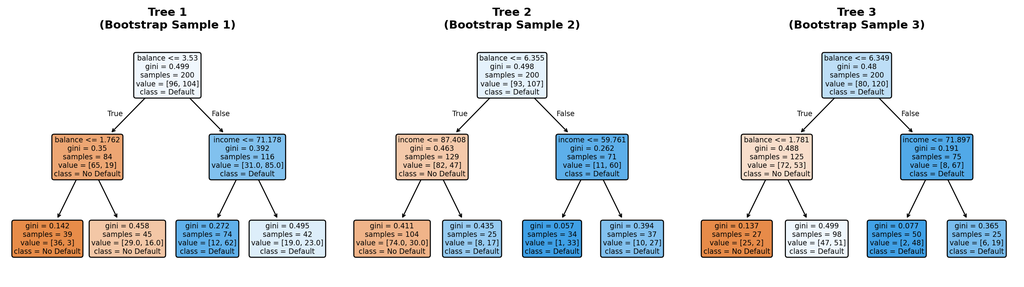

**Problem: Tree Correlation**

**Solution:** Force trees to use different features through **feature randomness**

## Feature Randomness: Secret Sauce

**At each split, consider only a random subset of features**

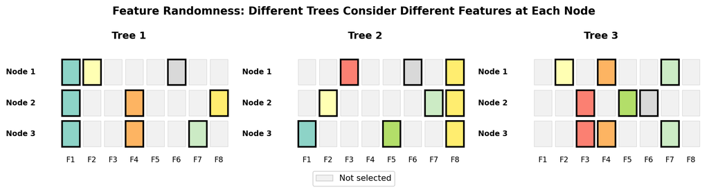

**How It Works:**

- At each split, randomly select subset of features
- **Classification**: √p features
- **Regression**: p/3 features
- Tree only considers these for that split

**The Result:**

- Different trees explore different features
- No single feature dominates all trees
- Trees become decorrelated
- More diverse predictions

## Impact of Feature Randomness

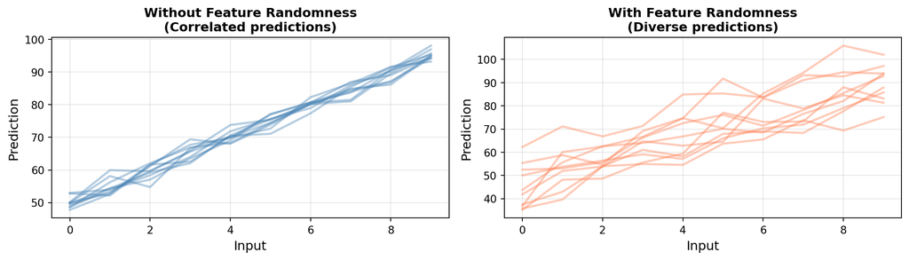

**Without Feature Randomness:**

- All trees use same dominant features
- Similar tree structures
- Correlated predictions (similar slopes)
- Limited benefit from averaging

**With Feature Randomness:**

- Trees forced to use different features
- Diverse tree structures
- Decorrelated predictions (varied slopes)
- Errors cancel out when averaged!

## The Power of Feature Randomness

**Random forests outperform bagged trees through decorrelation**

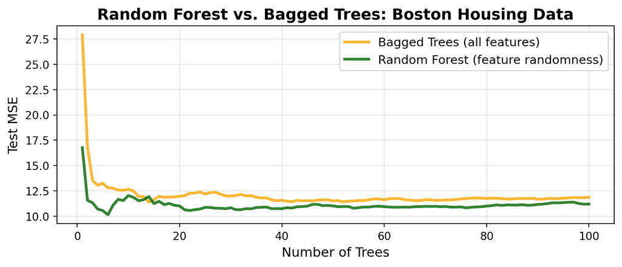

```
Final Performance (100 trees):
Bagged Trees MSE:  11.8729
Random Forest MSE: 11.1917
Improvement: 5.7%
```

**Key Insight**

Feature randomness **decorrelates** trees, allowing their errors to cancel out more effectively when averaged. This is why random forests consistently outperform simple bagged trees!

## Demo: Single Tree vs Random Forest

Let’s compare performance on the Boston housing dataset!

```python
from sklearn.tree import DecisionTreeRegressor
from sklearn.ensemble import RandomForestRegressor
from sklearn.metrics import root_mean_squared_error, r2_score

# Load Boston data (if not already loaded)
from ISLP import load_data
Boston = load_data('Boston')
X = Boston.drop('medv', axis=1)
y = Boston['medv']

# Split data
from sklearn.model_selection import train_test_split
X_train, X_test, y_train, y_test = train_test_split(X, y, test_size=0.3, random_state=42)

# Build Single Decision Tree
single_tree = DecisionTreeRegressor(max_depth=3, random_state=42)
single_tree.fit(X_train, y_train)

# Build Random Forest (100 trees)
rf_model = RandomForestRegressor(n_estimators=100, max_depth=3, random_state=42)
rf_model.fit(X_train, y_train)

# Compare performance
print("=== Single Decision Tree ===")
print(f"Training R²: {single_tree.score(X_train, y_train):.3f}")
print(f"Test R²: {single_tree.score(X_test, y_test):.3f}")
print(f"Test RMSE: ${root_mean_squared_error(y_test, single_tree.predict(X_test)):.2f}k")

print("\n=== Random Forest (100 trees) ===")
print(f"Training R²: {rf_model.score(X_train, y_train):.3f}")
print(f"Test R²: {rf_model.score(X_test, y_test):.3f}")
print(f"Test RMSE: ${root_mean_squared_error(y_test, rf_model.predict(X_test)):.2f}k")

print("\n=== Improvement ===")
r2_improvement = (rf_model.score(X_test, y_test) - single_tree.score(X_test, y_test)) / single_tree.score(X_test, y_test)
rmse_improvement = (root_mean_squared_error(y_test, single_tree.predict(X_test)) - root_mean_squared_error(y_test, rf_model.predict(X_test))) / root_mean_squared_error(y_test, single_tree.predict(X_test))
print(f"Test R² improvement: {r2_improvement*100:.2f}%")
print(f"Test RMSE improvement: {rmse_improvement*100:.2f}%")
```

```
=== Single Decision Tree ===
Training R²: 0.825
Test R²: 0.773
Test RMSE: $4.11k

=== Random Forest (100 trees) ===
Training R²: 0.878
Test R²: 0.805
Test RMSE: $3.81k

=== Improvement ===
Test R² improvement: 4.21%
Test RMSE improvement: 7.43%
```

## Key Insight: Errors Cancel, Signal Remains

```
flowchart LR
    A[Tree 1<br/>Prediction] --> D[Average]
    B[Tree 2<br/>Prediction] --> D
    C[Tree 3<br/>Prediction] --> D
    E[Tree ...<br/>Prediction] --> D
    F[Tree 100<br/>Prediction] --> D
    D --> G[Final<br/>Prediction]

    style D fill:#ffd700,stroke:#ff8c00,stroke-width:3px
    style G fill:#90ee90,stroke:#228b22,stroke-width:3px
```

**The Mathematics of Wisdom:**

- Each tree makes some errors
- But errors are **uncorrelated** (thanks to bootstrap + feature randomness)
- Tree 1 might overestimate, Tree 2 underestimate
- When averaged, errors tend to cancel out
- True patterns appear in most trees → reinforced
- Random noise appears in few trees → averaged away

**Result:** More accurate and stable predictions!

# Feature Importance: Opening the Black Box

## The Interpretability Challenge

**The Problem:** Your model is accurate, but can you explain *why*?

**The Trade-Off:**

```
flowchart LR
    A[Linear<br/>Regression] --> B[Decision<br/>Tree]
    B --> C[Random<br/>Forest]
    C --> D[Deep<br/>Learning]

    style A fill:#90EE90
    style B fill:#FFD700
    style C fill:#FFA07A
    style D fill:#FF6347
```

**As we move right:**

- Accuracy ↑ (Better predictions)
- Interpretability ↓ (Harder to explain)

**How We Interpret Each:**

**Linear Regression:**

- Coefficients tell the story
- “Each $1k income increases price by $45”
- Simple, direct interpretation ✓

**Decision Tree:**

- Visualize the tree structure
- Follow the if-then rules
- Trace individual predictions ✓

**Random Forest:**

- Aggregating 100-1000 trees
- Can’t visualize all trees
- No single path to trace ❌

## The Business Reality

**A Common Business Conversation:**

**You:** “Our Random Forest predicts customer churn with 94% accuracy!”

**VP:** “Excellent! So which customers are at risk and why?”

**You:** “Here’s a list of 500 high-risk customers.”

**VP:** “Great! What should we do to retain them?”

**You:** “Well… the model doesn’t exactly tell us that in a straightforward way…”

**VP:** “What do you mean? How can it predict churn without knowing what causes churn?”

**You:** “It does know—sort of. The patterns are just… distributed across hundreds of decision trees…”

**VP:** 🤔 “So you’re telling me to spend $200,000 on retention campaigns, but you can’t explain why these specific customers are at risk?”

**The Challenge**

Your model is accurate, but stakeholders need more than predictions—they need **explanations** and **actionable insights**.

## Why Feature Importance Matters

Feature importance helps us answer the critical business questions:

**Building Trust:**

- “Show me which factors drive your predictions”
- Stakeholders can validate against domain knowledge
- Catches data leakage and model errors early

**Supporting Decisions:**

- Translate predictions into strategy
- “Customers with 4+ service calls are at high churn risk → proactive outreach”
- Focus resources on what actually matters

**Feature Selection:**

- Out of 50 features, maybe only 8 drive meaningful predictions
- Simplify data collection
- Reduce noise, improve performance

**Regulatory Compliance:**

- Finance: Must explain why credit was denied
- Healthcare: Medical decisions must be explainable
- GDPR: “Right to explanation” for automated decisions

## Understanding Our Random Forest

**Two critical questions about our model:**

**Question 1: Which Features Matter Most?**

**Feature Importance** tells us which variables are driving our model’s predictions.

*Example:* “Balance is responsible for 70% of the model’s decision-making, while income contributes only 15%”

**Question 2: How Do They Influence Predictions?**

**Partial Dependence Plots** show us how predictions change as we vary an influential feature.

*Example:* “As balance increases from $0 to $2,000, default probability rises from 5% to 85%”

**Our Approach**

**First**, identify what matters → **Then**, understand how it matters

## Measuring What Matters

**Two approaches to identify influential features:**

**1. Gini/MSE Importance**

*How it works:*

- Tracks which features create the best splits
- Aggregates across all trees

*Pros:*

- Fast, built into scikit-learn
- Easy: `.feature_importances_`

*Cons:*

- Biased toward continuous features
- Uses training data only

**2. Permutation Importance**

*How it works:*

- Shuffle one feature at a time
- Measure performance drop

*Pros:*

- Works with any model
- More reliable rankings
- Uses test data

*Cons:*

- Slower computation
- Needs separate calculation

**Best Practice:**

Use Gini for quick checks → validate with permutation importance

## Demo: Extracting Feature Importance

Let’s see what drives housing price predictions in our Random Forest!

```
=== Top 5 Features (Gini Importance) ===
    feature  gini_importance
5        rm         0.470899
11    lstat         0.425896
7       dis         0.060453
0      crim         0.019015
10  ptratio         0.011493

=== Top 5 Features (Permutation Importance) ===
    feature  perm_importance
11    lstat         0.532376
5        rm         0.391215
7       dis         0.051826
10  ptratio         0.016935
0      crim         0.015026
```

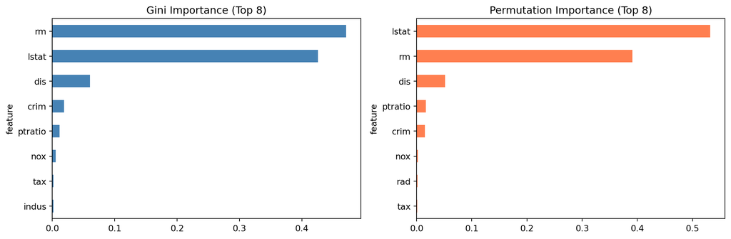

```python
import pandas as pd
from sklearn.inspection import permutation_importance
import matplotlib.pyplot as plt

# We already have our trained rf_model from the Boston housing demo
# Extract Gini-based importance
feature_names = X_train.columns
gini_importance = pd.DataFrame({
    'feature': feature_names,
    'gini_importance': rf_model.feature_importances_
}).sort_values('gini_importance', ascending=False)

print("=== Top 5 Features (Gini Importance) ===")
print(gini_importance.head())

# Calculate Permutation Importance on test set
perm_result = permutation_importance(
    rf_model, X_test, y_test,
    n_repeats=10, random_state=42, scoring='r2'
)

perm_importance = pd.DataFrame({
    'feature': feature_names,
    'perm_importance': perm_result.importances_mean
}).sort_values('perm_importance', ascending=False)

print("\n=== Top 5 Features (Permutation Importance) ===")
print(perm_importance.head())

# Visualize top 8 features
fig, (ax1, ax2) = plt.subplots(1, 2, figsize=(12, 4))
gini_importance.head(8).sort_values('gini_importance').set_index('feature')['gini_importance'].plot(
    kind='barh', ax=ax1, color='steelblue', title='Gini Importance (Top 8)'
)
perm_importance.head(8).sort_values('perm_importance').set_index('feature')['perm_importance'].plot(
    kind='barh', ax=ax2, color='coral', title='Permutation Importance (Top 8)'
)
plt.tight_layout()
plt.show()
```

## Understanding How Features Influence Predictions

**Feature importance tells us WHICH features matter, but not HOW they matter**

**What We Know:**

**What We Don’t Know:**

- Does increasing `lstat` increase or decrease price?
- Is the relationship linear or non-linear?
- Are there threshold effects?
- At what point does the effect saturate?

**Enter: Partial Dependence Plots (PDPs)**

PDPs show **how predictions change** as we vary one feature while holding all others constant.

This is actionable intelligence!

## Demo: Creating Partial Dependence Plots

Let’s visualize how `lstat` affects housing prices!

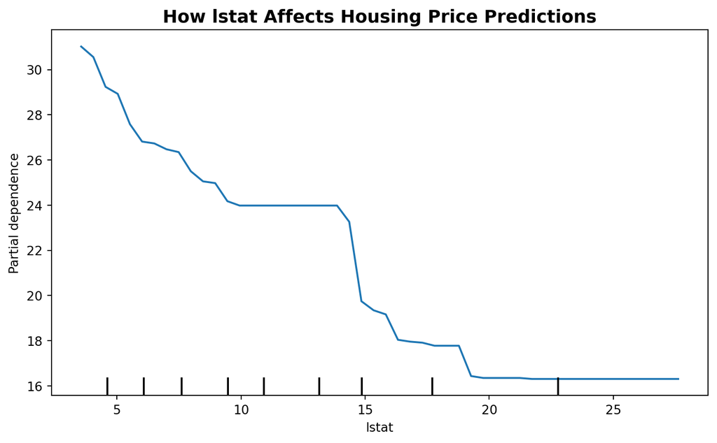

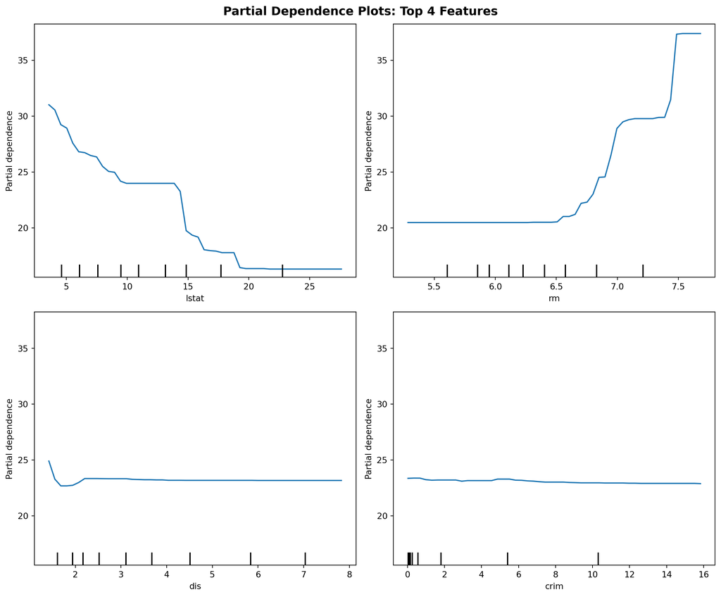

```python
from sklearn.inspection import PartialDependenceDisplay

# Create PDP for lstat (our most important feature)
fig, ax = plt.subplots(figsize=(8, 5))
PartialDependenceDisplay.from_estimator(
    rf_model,
    X_train,
    features=['lstat'],
    grid_resolution=50,
    ax=ax
)
plt.title('How lstat Affects Housing Price Predictions', fontsize=14, fontweight='bold')
plt.tight_layout()
plt.show()

# Create PDPs for multiple top features
fig, axes = plt.subplots(2, 2, figsize=(12, 10))
axes = axes.ravel()

top_features = ['lstat', 'rm', 'dis', 'crim']  # Top 4 features
PartialDependenceDisplay.from_estimator(
    rf_model,
    X_train,
    features=top_features,
    grid_resolution=50,
    ax=axes
)
plt.suptitle('Partial Dependence Plots: Top 4 Features', fontsize=14, fontweight='bold')
plt.tight_layout()
plt.show()
```

# Wrap-Up & Looking Ahead

## Key Takeaways

- **Decision Trees** – Learn patterns through sequential yes/no questions, automatically discovering thresholds and interactions, but can be unstable and prone to overfitting.
- **Random Forests** – Combine hundreds of diverse trees (via bootstrap sampling and feature randomness) to create stable, accurate predictions through voting or averaging.
- **Feature Importance** – Bridges the gap between accuracy and interpretability, revealing which features drive predictions and enabling stakeholder trust and actionable insights.
- **The Big Picture** – Tree-based models offer a powerful middle ground between simple linear models and complex black boxes, delivering strong performance with reasonable interpretability.

## Looking Ahead

**Between now and Thursday:**

- Read Chapters 25-27 (Decision Trees, Random Forests, Feature Importance)

**Thursday’s Lab:**

- Hands-on applications with decision trees, random forests, and feature importance

**Homework:**

- Thursday’s lab will feed into the homework assignment

## Any Final Questions?

- About today’s concepts?
- About Thursday’s lab?
- About the readings?

**See you Thursday for hands-on practice!**

*“The best way to learn tree-based models is to build them yourself.”*